# Quaternary Mammals

Let’s load the packages that we need, and also specify that we want to use `theme_minimal()` for all plots. The `16` that I provide to this function just specifies a larger font size, since the default is a little small (the default is 11 pt font).

```r
library("tidyverse")
library("ggridges")
library("here")

theme_set(theme_minimal(16))

# Read in the data
# MODIFY AS NEEDED! E.g., "week5/data/late_quaternary_mammals.RDS" or whatever
lqm <- readRDS(here("05_viz-distributions/data/late_quaternary_mammals.RDS"))
```

## Histograms

#### Exploring different bin settings

Make a histogram of log_mass with exactly 15 bins, with the boundary of the first bin starting at 0.

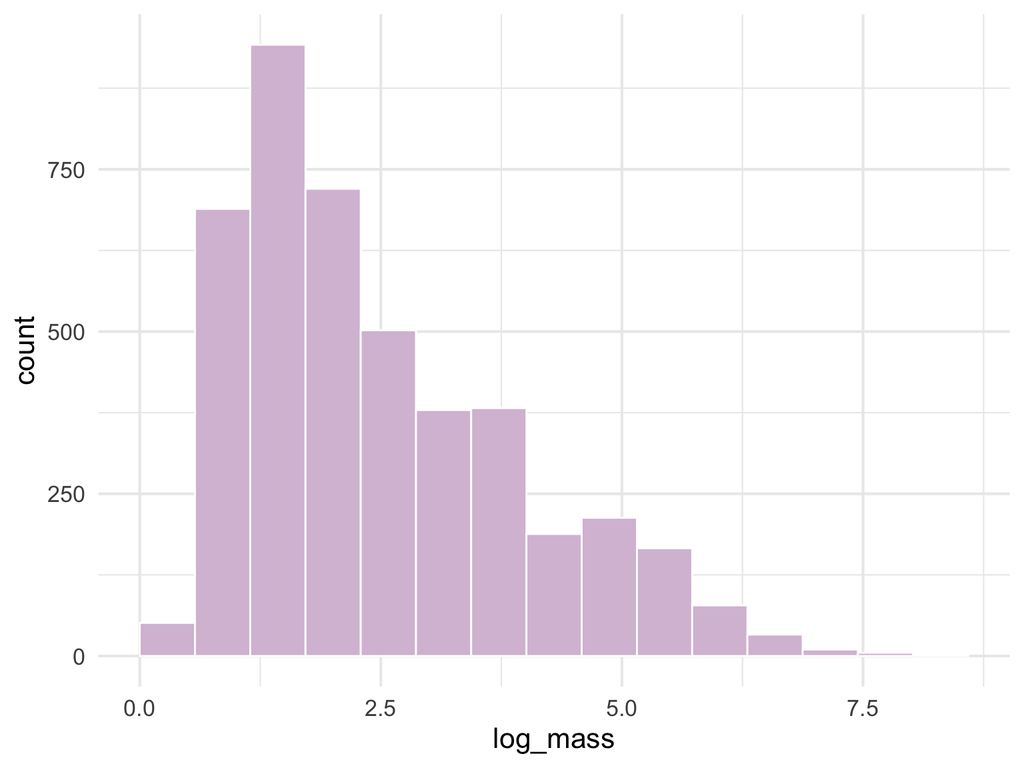

Make a histogram of log_mass with bins that are exactly 0.25 units of log_mass wide, with the boundary of the first bin starting at 0.

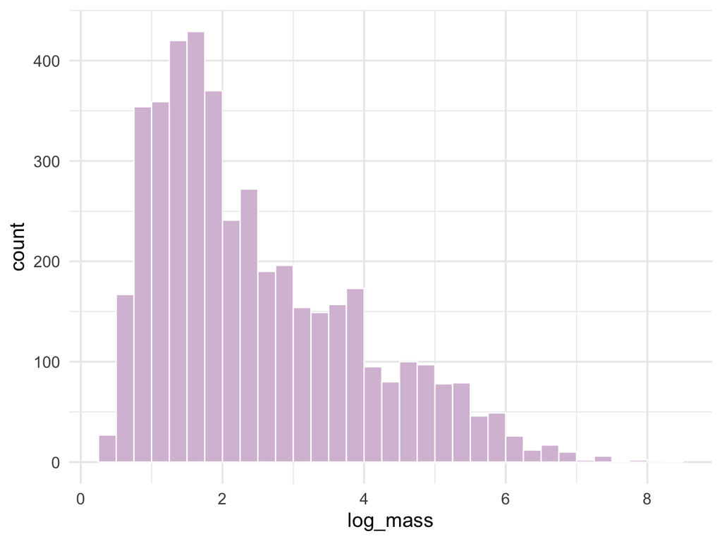

Make a histogram of log_mass and use the `breaks` argument to make bin breaks at each 0.5 unit interval between 0 and 8, with the boundary of the first bin starting at 0. Hint: use the `seq()` function to make a regular sequence. Example usage (you’ll need to modify): `seq(from = 1, to = 2, by = 0.1)`

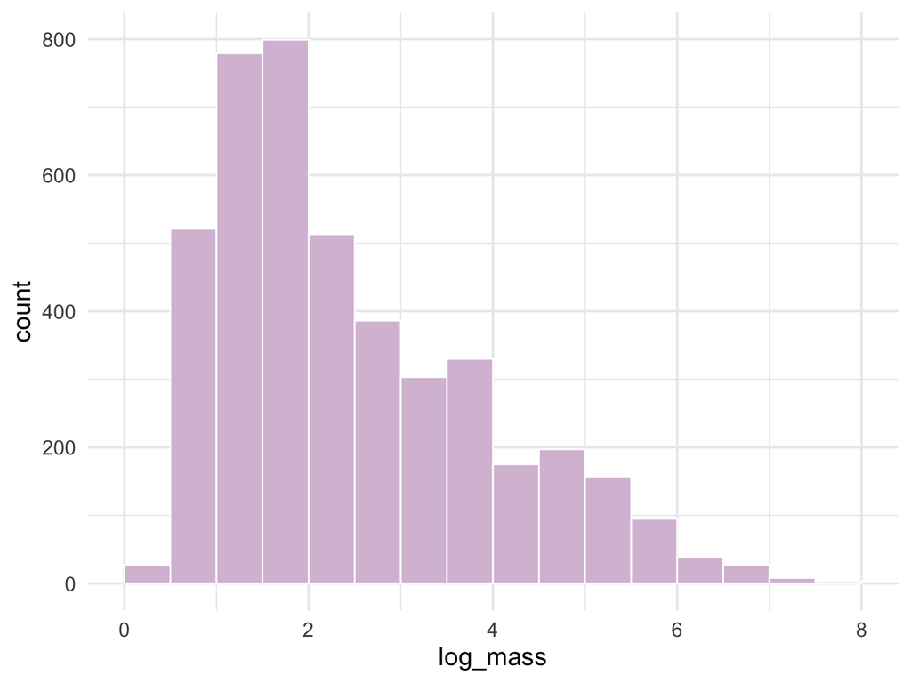

#### Faceting

Make a plot of small multiples with a histogram of log_mass for each continent. To visualize the distributions more clearly, allow the y-axis scale to vary among the small multiples, but keep the same x-axis scale for all. Set the bin positions however you want.

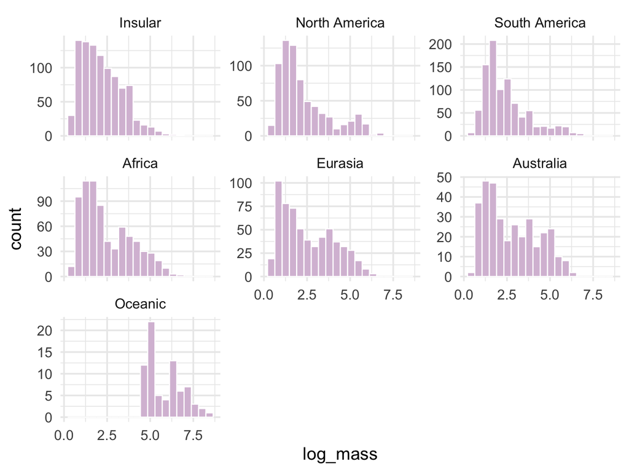

#### Age-pyramid plots

Reproduce the vertical age-pyramid-style histogram plot that we saw in class comparing the distributions of log_mass for North America and Oceanic late Quaternary mammals.

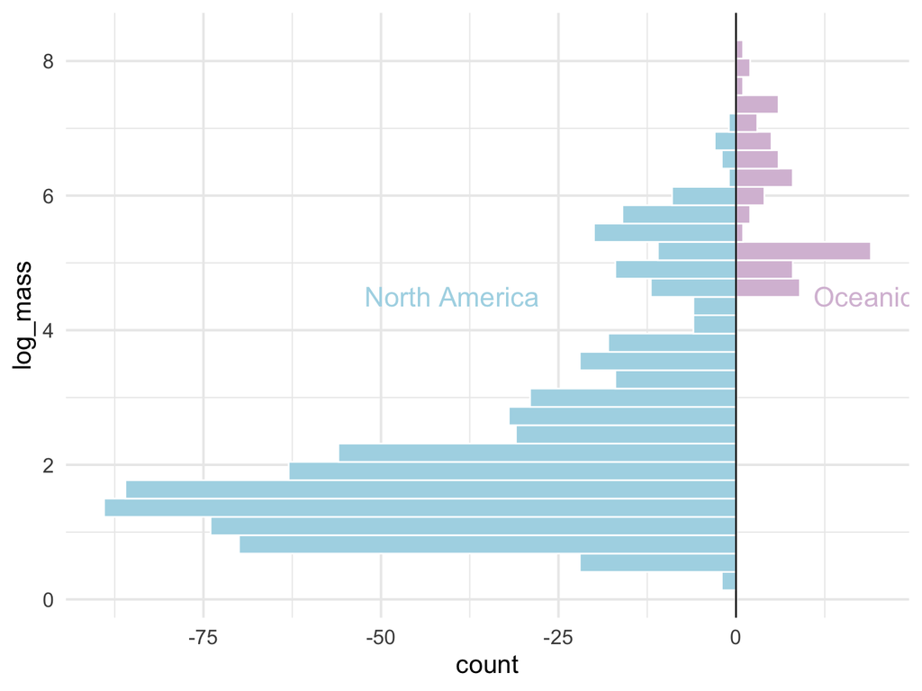

Do the same but use density plots instead. Note that the calculated stat variable in your aesthetic mapping changes from count to density.

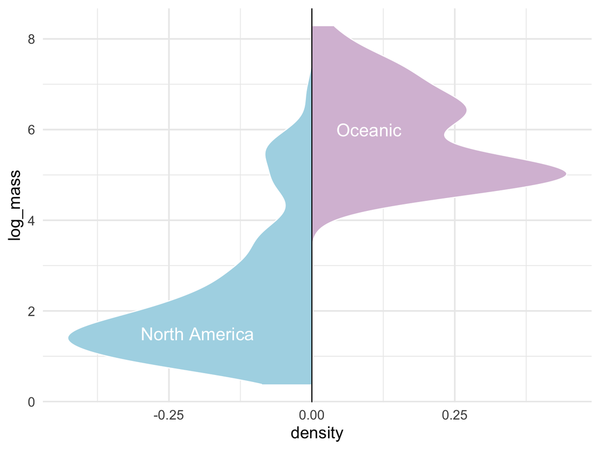

#### Overlapping densities

Make an overlapping density plot of log_mass using a different fill color for each continent. Use transparency, and note that the densities are more easily separable if they’re outlined in some contrasting color (e.g., white or black).

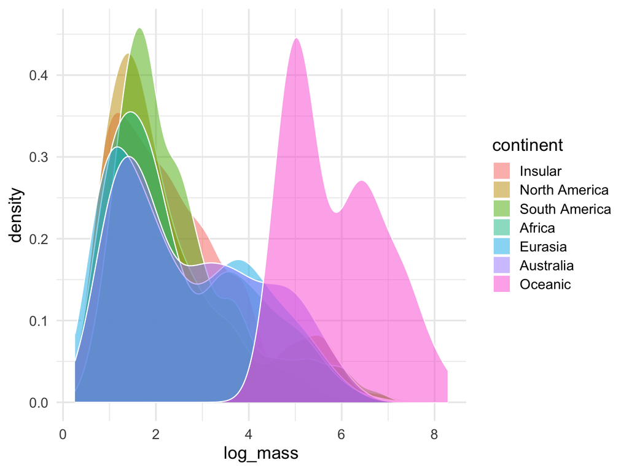

#### Ridgeline plots

Make a ridgeline plot of log_mass by Order of mammals. The data set is already ordered so that the Order with the largest mean log_mass appears on top. But for this plot, reorder the Orders by the smallest member of each order using `fct_reorder()`. Hint: in `fct_reorder()`, if there are multiple values of the column that you want to reorder by (log_mass) for each category value (order)—which there are here—then by default it uses the median value. In this case, you want to specify that it should use the *min* value rather than the median value using the .fun argument:

`... y = fct_reorder(<column to reorder>, <column to reorder by>, .fun = <the new function to use>) ...`

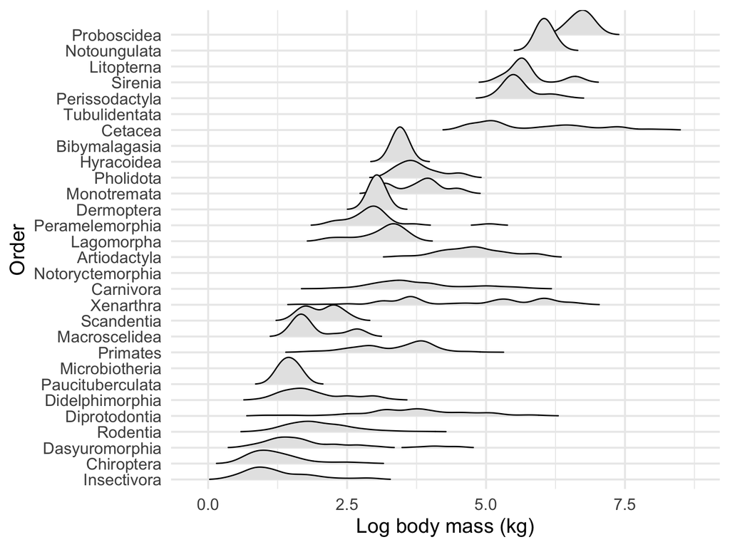

Make the gradient ridgeline plot that we saw in class of log_mass for each Order. To get the color palette in the solutions file, add `scale_fill_viridis_c(option = "plasma")` to your plot.

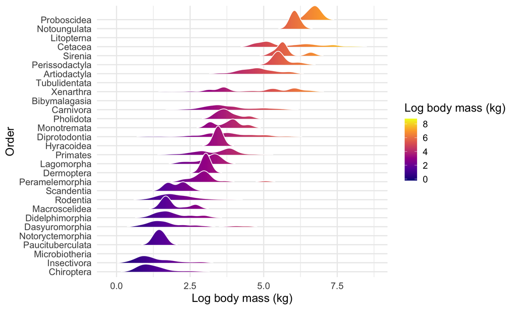